# Lab 5: Simple linear regression

Chang-Hsin Lee

October 18, 2016

In this lab, we will learn an important statistical learning method caleed *linear regression*. Although the idea is straightforward, many fancy methods in the field of machine learning like neural network and support vector machines are generalizations of linear regression. A regression problem is a type of *supervised learning* problem, where the goal is to predict a continuous valued response $Y$ from a vector of predictors $X$ by learning their relationship as a function $h$. You may see people call predictor and response by other names depending on the field of study. Here are some commonly used synonyms.

- predictor = independent variable = controlled variable = feature = input variable
- response = dependent variable = target = output variable

## Simple linear rergression

The simplest parametrized regression method is the simple linear regression, which fits a straight line between a continuous predictor $X$ and the response $Y$. By fitting we mean finding suitable numbers $\beta_{1}$ and $\beta_{2}$ in the linear relationship

$$Y \approx \beta_{1} + \beta_{2} X.$$

If we denote the training data by pairs of numbers

$$(x_1,y_1), \, (x_2,y_2) \, \ldots (x_N,y_N)$$

and the corresponding estimate from linear regression by $\hat{y}_1, \hat{y}_2, \ldots , \hat{y}_N$ obtained from

$$\hat{y}_i = \beta_1 + \beta_2 \cdot x_i,$$

then linear regression seeks $\beta_1, \beta_2$ so that the residual sums of squares (RSS)

$$\sum\limits_{i=1}^{N} (y_{i} - \hat{y}_i)^{2}$$

is minimized. For this reason, $\beta_{1}$ and $\beta_{2}$ are called parameters of the model. In R, linear regression is fitted with the linear model function `lm()`. Here I will demonstrate with the dataset `Boston` from package `MASS` following the book [Introduction to Statistical Learning](http://www-bcf.usc.edu/~gareth/ISL/)

```r
library(MASS)
data(Boston)
names(Boston)
```

```
##  [1] "crim"    "zn"      "indus"   "chas"    "nox"     "rm"      "age"
##  [8] "dis"     "rad"     "tax"     "ptratio" "black"   "lstat"   "medv"
```

Let’s start with using `lstat` as the predictor and `medv` as the response. The fitting formula is specified in `lm()` with a wiggle `~` implying that we are fitting `y ~ x`.

```r
fit1 <- lm(medv ~ lstat, data = Boston)
summary(fit1)
```

```
##
## Call:
## lm(formula = medv ~ lstat, data = Boston)
##
## Residuals:
##     Min      1Q  Median      3Q     Max
## -15.168  -3.990  -1.318   2.034  24.500
##
## Coefficients:
##             Estimate Std. Error t value Pr(>|t|)
## (Intercept) 34.55384    0.56263   61.41   <2e-16 ***
## lstat       -0.95005    0.03873  -24.53   <2e-16 ***
## ---
## Signif. codes:  0 '***' 0.001 '**' 0.01 '*' 0.05 '.' 0.1 ' ' 1
##
## Residual standard error: 6.216 on 504 degrees of freedom
## Multiple R-squared:  0.5441, Adjusted R-squared:  0.5432
## F-statistic: 601.6 on 1 and 504 DF,  p-value: < 2.2e-16
```

The `lm()` function produces a linear fit whose coefficients we can access by calling the object. `broom` by David Robinson is a good package to use when we want to extract numbers from the fit. I will clean up the fit object with the `tidy()` function.

```r
library(broom)
coeff.fit1 <- tidy(fit1)
coeff.fit1
```

```
##          term   estimate  std.error statistic       p.value
## 1 (Intercept) 34.5538409 0.56262735  61.41515 3.743081e-236
## 2       lstat -0.9500494 0.03873342 -24.52790  5.081103e-88
```

In this case, $\beta_{1}=$ `34.5538409` and $\beta_{2}=$ `-0.9500494`. Using ggplot2, I can make a plot of this linear fit by either specifying the statistical transformation or by adding a line to the plot:

```r
library(ggplot2)
# The easy way
ggplot(Boston, aes(x = lstat, y = medv)) + geom_point() +
  geom_smooth(method = "lm", se = FALSE)
```

[output not shown]

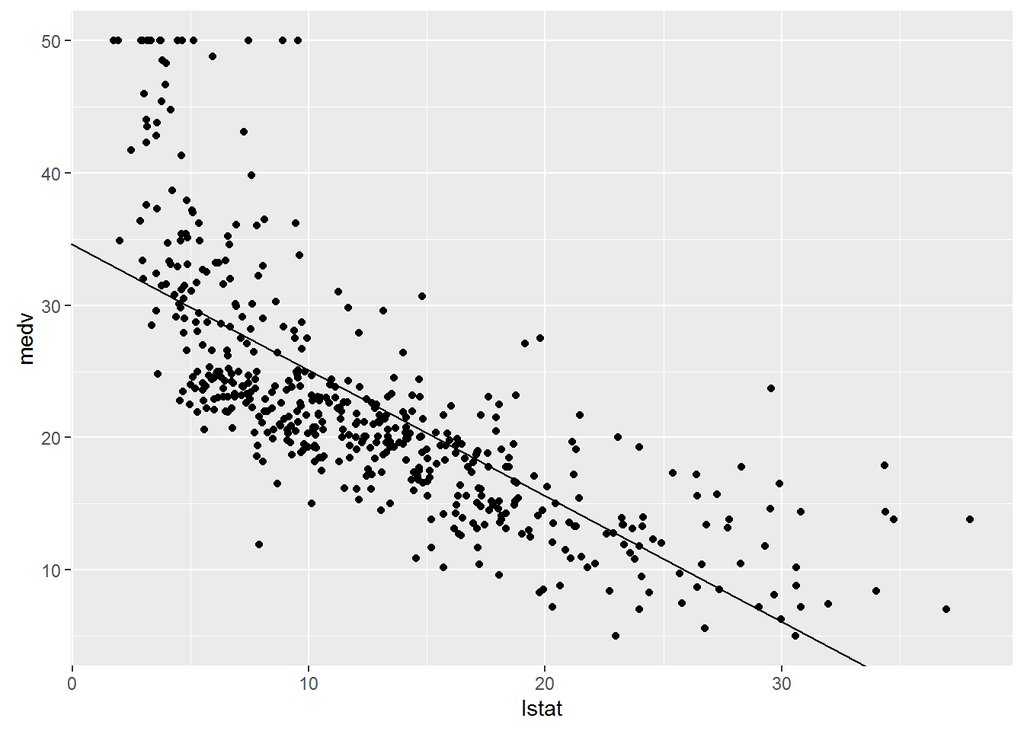

```r
# The hard way, but customizable
ggplot(Boston, aes(x = lstat, y = medv)) + geom_point() +
  geom_abline(intercept = coeff.fit1$estimate[1], slope = coeff.fit1$estimate[2])
```

## Accuracy of regression

When is a linear regression a good fit? Because linear regression minimizes the sum of squares of errors, two common quantaties related to the quality of fit are the *residual standard error* (RSE) and the $R^{2}$ statistic.

### RSE

The residual standard error (RSE) is defined as

$$\mbox{RSE} = \sqrt{\dfrac{1}{n-2} \mbox{RSS}} = \sqrt{\dfrac{1}{n-2} \sum\limits_{i=1}^{N} (y_{i} - \hat{y}_i)^{2}}.$$

Note that RSE is an unbiased estimator for variance because of the $n-2$ with 2 degrees of freedom (much like the reason people put $n-1$ in sample variance.) In my example, RSE = `6.2157604`.

### $R^{2}$

RSE is an absolute measure of the lack of fit in the units of $Y$. Sometimes it is unclear what is a good RSE for the fit. Alternatively, the $R^{2}$ statistic (or coefficient of determination) provides a relative measure of fit between 0 and 1. Another way to understand $R^{2}$ is also understood as *proportion of variance explained*. The formula for $R^{2}$ is

$$R^{2} = \dfrac{\mbox{TSS} - \mbox{RSS}}{\mbox{TSS}} = 1 - \dfrac{RSS}{TSS},$$

where $\mbox{TSS} = \sum(\bar{y}_{i} - y)^{2}$ is the *total sums of squares*. An $R^{2}$ close to 1 means a large proportion of variance has been explained by the regression. In fact, in the simple regression setting $R^{2}$ is simply the square of sample coefficient of correlation $\mbox{Cor}(X,Y)$ between $X$ and $Y$:

$$R^{2} = \mbox{Cor}(X,Y)^{2}.$$

However, the idea of correlation does not extend naturally to the setting of multiple linear regression where there are multiple predictors. In that case, $R^{2}$ still works as a measure of quality of fit. Keep in mind that there is no cut and dried $R^{2}$ value for a “good fit”. Depending on the situation, even an $R^{2}$ of 0.2 may be considered good. In our example, $R^{2}$ =`0.5441463`, which in my opinion is pretty good.

## p-value

- p-value does not measure the size of an effect, and
- by itself p-value does not provide a good measure of evidence regarding a model or hypothesis.

Never draw conclusions from *only* p-values!